# Ocean Conservancy, Urban Ocean Marine Debris Prediction

Trevor Kapuvari, Shreya Bansal, Tianxiao Chen, Stephanie Cheng, Xiaofan Liu

University of Pennsylvania

2024-02-27

# 1 Introduction

The Ocean Conservancy’s Urban Ocean program has been developing projects that mitigate marine pollution, assess waste management, and enable cities to address ocean plastics and resilience. These projects intend to deploy “zero-waste” pilot solutions in multiple cities where they have partnerships and have collected waste management information. Our objective is to develop a environmental remediation assessment model that identifies effective zero-waste site locations for national and multinational use. This geospatial assessment model serves the purpose of predicting litter accumulation based on globally sourced data with a repeatable framework on an international scale. The results of the model evaluate which sections of a given area have the highest likelihood to produce and contain litter relative to its surroundings. For our case, the Urban Ocean program intends to dedicate “zero-waste” solutions in these areas for the most effective impact for each deployment.

```r
countfishnet <- function(fishnet,dataset){
  net <-
  dplyr::select(dataset) %>%
  mutate(count = 1) %>%
  aggregate(., fishnet, sum) %>%
  mutate(count = replace_na(count, 0),
         uniqueID = 1:n(),
         cvID = sample(round(nrow(fishnet) / 24),
                       size=nrow(fishnet), replace = TRUE))
  return(net)
}

knnfishnet <- function(fishnet,dataset,knum){
  vars_net <- dataset%>%
    st_join(fishnet, join=st_within) %>%
    st_drop_geometry() %>%
    group_by(uniqueID,osm_id) %>%
    summarize(count = n()) %>%
    left_join(fishnet, ., by = "uniqueID") %>%
    spread(osm_id, count, fill=0) %>%
    dplyr::select(-`<NA>`) %>%
    ungroup()
  vars_net <- vars_net %>%
    mutate(item.nn = nn_function(st_c(st_coid(vars_net)),
                                           st_c(dataset),
                                           k = knum))
  return(vars_net)
}

visual <- function(net_one,point_one,variable_name){
grid.arrange(
  ggplot() +
  geom_sf(data = net_one, aes(fill = count), color = NA) +
  scale_fill_viridis() +
  labs(title = paste(variable_name,"count for the fishnet")) +
  mapTheme(),
  ggplot() +
  geom_sf(data = chen_bdry) +
  geom_sf(data = point_one, colour="red", size=0.2, show.legend = "point") +
  labs(title= paste(variable_name,", Chennai")) +
  mapTheme(title_size = 14),
  nrow = 1
)
}
```

```r
litter <- read.csv('https://raw.githubusercontent.com/TrevorKap/MUSA810-Marine-Pollution/main/Data/mdt-dataChennai.csv')

litter_p <- litter%>%
  filter(master_material == 'PLASTIC')%>%
  st_as_sf(coords = c("longitude", "latitude"), crs = 4326, agr = "constant")%>%
  st_transform('EPSG:32643')

chen_bdry <- st_read('https://raw.githubusercontent.com/TrevorKap/MUSA810-Marine-Pollution/main/Data/gcc-divisions-latest.kml')
chen_bdry <- st_set_crs(chen_bdry, 4326)%>%
  st_transform('EPSG:32643')

fishnet <-
  st_make_grid(chen_bdry,
               cellsize = 500,
               square = TRUE) %>%
  .[chen_bdry] %>%
  st_sf() %>%
  mutate(uniqueID = 1:n())

litter_people <- litter_p%>%
  group_by(username)%>%
  tally()
```

# 2 Methodology

For our first model, we directed our focus on Chennai, India. The data regarding the region and its attributes was sourced from OpenStreetMaps (OSM) to ensure a repeatable framework & quality consistency. For each selected city we developed a ‘boundary box’ automated by OSM simply by specifying the name of the area (city & nation) and using the output coordinates as the scope of data acquisition. From there, further attributes of the area with respect to structures, networks, or political divisions can be extracted for use.

The data gathered takes various formats, mostly in vector-based formats such as lines, points, and polygons. For our assessment, these datasets were re-formatted to raster layers measuring count, nearest neighbor, or other spatial attributes. This uniformity allows the model to compare the attributes against each variable and visualize contrast throughout the studied region.

In terms of our dependent variable, litter data, the process required manually downloading data from Marine Debris Tracker (https://www.debristracker.org/data/). Each selected city required its own evaluation in terms of quantitative debris data over a several year time span. Ideal locations featured several thousand data points across 2-3 years for early-stage model development. Despite the scalability of the model itself, results and accuracy lay contingent on data quantity and external factors.

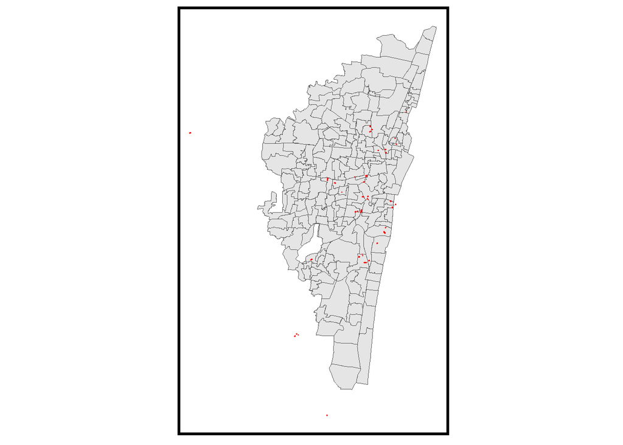

```r
grid.arrange(
  ggplot() +
  geom_sf(data = chen_bdry) +
  geom_sf(data = litter_p, colour="red", size=0.2, show.legend = "point") +
 # geom_sf(data = litter_p%>%filter(username == 'Chandranram'), colour="green", size=0.2, show.legend = "point") +
  mapTheme(title_size = 14),
  nrow = 1
)
```

The litter data featured a wide variety of item categories and general information about each piece. Despite the quality of detail for each recorded sample, this only accounts for litter that has been identified, recorded, and disposed of. This data does not account for litter that was identified but never disposed of, accounted for, or assumed. Regardless, areas where litter was not recorded in a general surrounding could not confidently be assumed to be present or not present.

## 2.1 Marine Debris Data, in Summary

Each chart below visualizes the observed litter data from the Marine Debris Tracker (MDT). The most important feature we looked at in predicting accumulation or the possibility of additional unrecorded samples were quantity, altitude, and radius.

Quantity measured groupings of specific litter samples that were disposed of at the same time & place.

Altitude measured the elevation of recorded litter, ranging widely between steep terrain throughout Chennai or holes/ditches far below sea level.

Radius functioned as a confidence interval for coordinates and known accuracy of where the litter was recorded, majority of which had consistent readings with notably some outliers.

The bar chart of ‘Main Item Category’ measures each type of litter found in the dataset, the project goals focused heavily on plastic and plastic-related waste. As a result, the largest counts of items measured are plastic-based products.

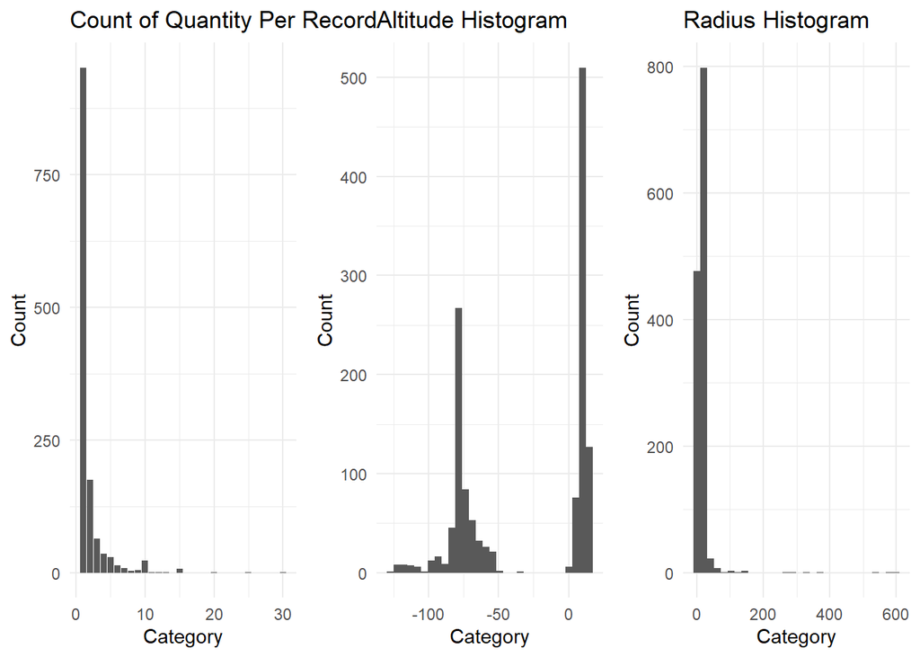

```r
grid.arrange(
  ggplot(litter_p, aes(x = quantity)) +
  geom_bar() +
  theme_minimal() +
  labs(title = "Count of Quantity Per Record",
       x = "Category",
       y = "Count"),
  ggplot(litter_p, aes(x = altitude)) +
  geom_histogram() +
  theme_minimal() +
  labs(title = "Altitude Histogram",
       x = "Category",
       y = "Count"),
  ggplot(litter_p, aes(x = radius)) +
  geom_histogram() +
  theme_minimal() +
  labs(title = "Radius Histogram",
       x = "Category",
       y = "Count"),
  ncol = 3
)
```

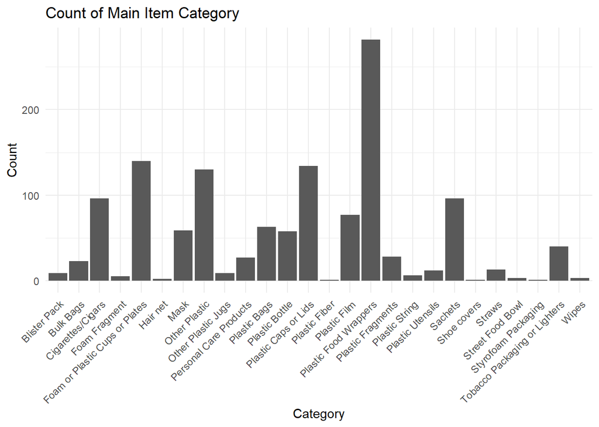

```r
ggplot(litter_p, aes(x = master_item_name)) +
  geom_bar() +
  theme_minimal() +
  labs(title = "Count of Main Item Category",
       x = "Category",
       y = "Count")+
  theme(axis.text.x = element_text(angle = 45, hjust = 1))
```

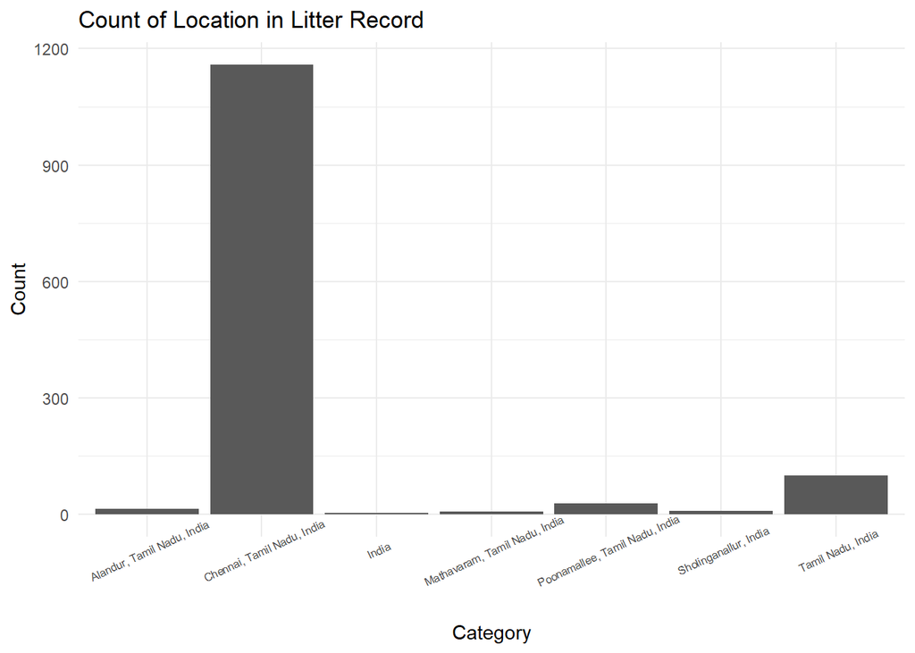

```r
ggplot(litter_p, aes(x = location)) +
  geom_bar() +
  theme_minimal() +
  labs(title = "Count of Location in Litter Record",
       x = "Category",
       y = "Count")+
  theme(axis.text.x = element_text(angle = 25,size = 6))
```

## 2.2 Chennai Debris Analysis

Using Chennai boundaries and MDT litter, we evaluated Chennai’s litter data situation through a fishnet grid. The fishnet grid allows us to categorize the city into uniformed sections, identify concentrations of data, and allow our model to quantify predictions in terms of quantity by cell rather than by precise locations.

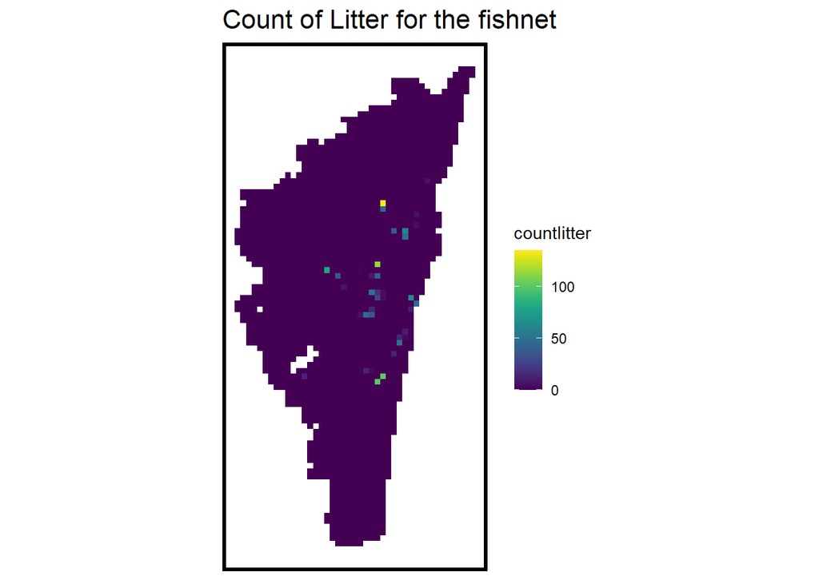

```r
litter_net <-
  dplyr::select(litter_p) %>%
  mutate(countlitter = 1) %>%
  aggregate(., fishnet, sum) %>%
  mutate(countlitter = replace_na(countlitter, 0),
         uniqueID = 1:n(),
         cvID = sample(round(nrow(fishnet) / 24),
                       size=nrow(fishnet), replace = TRUE))

ggplot() +
  geom_sf(data = litter_net, aes(fill = countlitter), color = NA) +
  scale_fill_viridis() +
  labs(title = "Count of Litter for the fishnet") +
  mapTheme()
```

# 3 Data Gathering and Variables

Our variable selection were based on our hypothesis of areas of human activity leading to higher litter assessment. The aim of these variables is to act as proxies for litter cases, providing insight on where litter most likely accumulated or ends up. These variables, similarly to litter, are analyzed on a fishnet grid where the quantity is counted per cell. Each variable is then placed on a combined fishnet grid with the litter data, computed using a Chi-Squared test, and evaluated for association between the variables and litter.

## 3.1 OpenStreetMap Variable Acquisition

Our variables acquired to compare correlations include waste management facilities, bodies of water, parks, land use, roadways, food-service amenities, and apartments. Below features the code example for OSM variable & city boundary defining & gathering.

```r
# reference: https://wiki.openstreetmap.org/wiki/Map_features#Entertainment,_Arts_&_Culture
amenity_wm <- c('waste_basket','waste_disposal','waste_transfer_station','recycling')
water<- c('canal','drain','ditch')
leisure <- c('park')
landuse <- c('commercial','residential','retail')
highway <- c('motorway','trunk','primary','secondary','tertiary','unclassified','residential')
act <- c('maxspeed')
amenity_food <- c('restaurant','pub','bar')

building <- ('apartments,')
```

```r
india <- getbb(place_name = "india", format_out = "polygon")
bb_df <- getbb(place_name = "chennai india", format_out = "data.frame")
bdry <- bb_df$boundingbox
chen_bd <- c(80.4301860, 13.2436939, 80.1101860, 12.8236939)
```

```r
bb_mb <- getbb(place_name = "mumbai india", format_out = "data.frame")
```

```r
trans <- opq(bbox = chen_bd) %>%
    add_osm_feature(key = 'highway', value = 'residential')%>%
  osmdata_sf()

trans_point <- bind_rows(
  pluck(trans,'osm_points'),
  st_centroid(pluck(trans,'osm_lines')))%>%
  dplyr::select(osm_id,geometry)%>%
  st_transform('EPSG:32643')%>%
  mutate(legend = 'road')

road_net <- countfishnet(fishnet,trans_point)
vars_net <- knnfishnet(fishnet,trans_point,3)
```

## 3.2 Independent Variables Examined

### 3.2.1 Residential Roads, Fishnet & Raw Data

To interpret data uniformly, we add our independent variables on a fishnet grid as shown below. Notably, using the raw value/geometry of each set does not assist with visual display or comprehension of data.

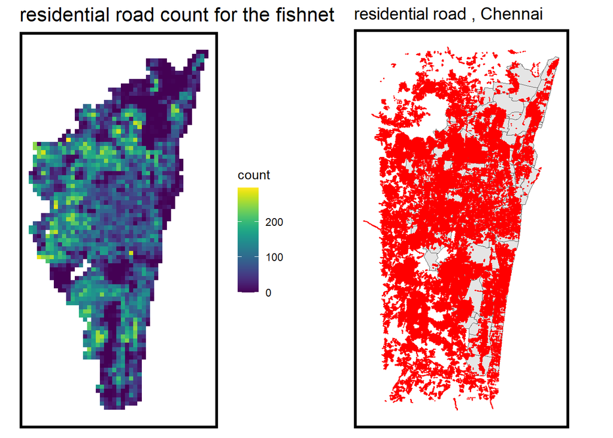

```r
visual(road_net,trans_point,'residential road')
```

```r
litter_no <- st_drop_geometry(litter_net)%>%dplyr::select(countlitter, uniqueID)
corr_trans_net <- road_net %>%
  left_join(litter_no, by = "uniqueID")
print(chisq.test(corr_trans_net$count,corr_trans_net$countlitter))
```

```
##
##  Pearson's Chi-squared test
##
## data:  corr_trans_net$count and corr_trans_net$countlitter
## X-squared = 6586.5, df = 7308, p-value = 1
```

### 3.2.2 Restaurants, Fishnet & Raw Data

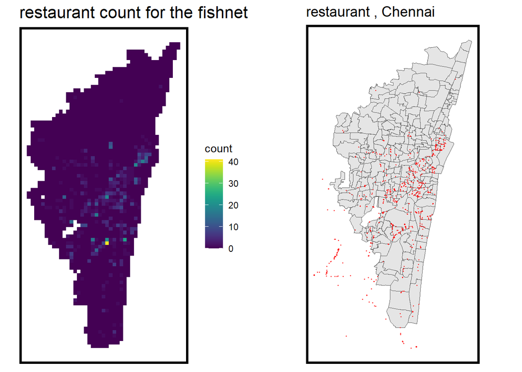

```r
restrt <- opq(bbox = chen_bd) %>%
    add_osm_feature(key = 'amenity', value = c('restaurant','pub','bar'))%>%
  osmdata_sf()

restrt_point <- pluck(restrt,'osm_points')%>%
  dplyr::select(osm_id,geometry)%>%
  st_transform('EPSG:32643')%>%
  mutate(legend = 'restaurant')

rstrt_net <- countfishnet(fishnet,restrt_point)
visual(rstrt_net,restrt_point,'restaurant')
```

```r
corr_net <- rstrt_net %>%
  left_join(litter_no, by = "uniqueID")

print(chisq.test(corr_net$count,corr_net$countlitter))
```

```
##
##  Pearson's Chi-squared test
##
## data:  corr_net$count and corr_net$countlitter
## X-squared = 881.98, df = 560, p-value < 2.2e-16
```

#### 3.2.2.1 Nearest Neighbor Fishnet, Restaurants

For specific variables such as restaurants, we wanted to examine a nearest neighbor analysis because of their direct implication with high human activity, excess flow of goods, and interconnection of urban systems. Areas of low distances of a “nearest neighbor” imply restaurants are close to one another geographically, indicate density in resources, and identify an urban core.

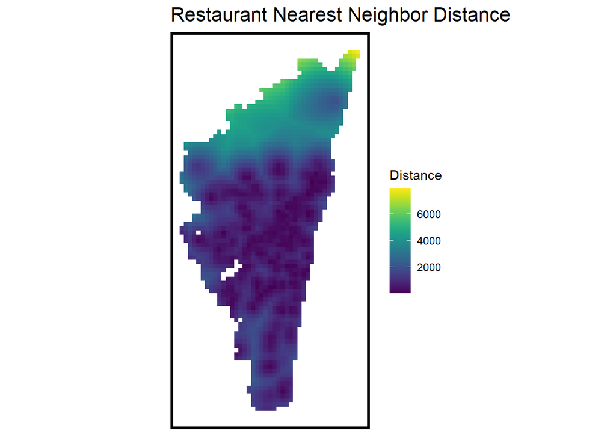

```r
vars_net_rstrt <- knnfishnet(fishnet,restrt_point,3)

vars_net_rstrt.long.nn <-
  dplyr::select(vars_net_rstrt, ends_with(".nn")) %>%
    gather(Variable, value, -geometry)

ggplot() +
      geom_sf(data = vars_net_rstrt.long.nn, aes(fill=value), colour=NA) +
      scale_fill_viridis(name="Distance") +
      labs(title="Restaurant Nearest Neighbor Distance") +
      mapTheme()
```

### 3.2.3 In-land Water Distribution

Water was an additional indicator to be further examined due to the physical circumstances surrounding marine debris. Often times, when litter/waste ends up in water, the waste will not naturally exit the body of water and reside on nearby shore or be carried to other bodies. These areas are also a heavier focus by Urban Oceans as marine pollution is a key focus.

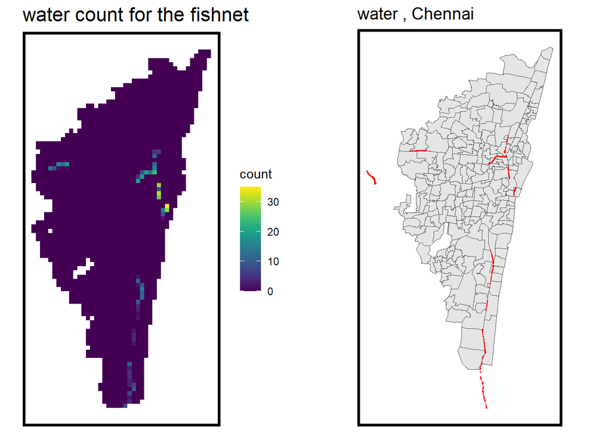

```r
chen_water <- opq(bbox = chen_bd) %>%
    add_osm_feature(key = 'water', value = water)%>%
  osmdata_sf()

chen_water_point <- pluck(chen_water,'osm_points')%>%
  dplyr::select(osm_id,geometry)%>%
  st_transform('EPSG:32643')%>%
  mutate(legend = 'water')

water_net <- countfishnet(fishnet,chen_water_point)
visual(water_net,chen_water_point,'water')
```

```r
corr_water_net <- water_net %>%
  left_join(litter_no, by = "uniqueID")
print(chisq.test(corr_water_net$count,corr_water_net$countlitter))
```

```
##
##  Pearson's Chi-squared test
##
## data:  corr_water_net$count and corr_water_net$countlitter
## X-squared = 1237.8, df = 616, p-value < 2.2e-16
```

#### 3.2.3.1 Nearest Neighbor, In-land Water Distribution

On this fishnet grid we notice sections adjacent to the coastline (east) create two centers with low ‘nearest neighbor’ values, also places that loosely defined outlined sections similar to restaurants.

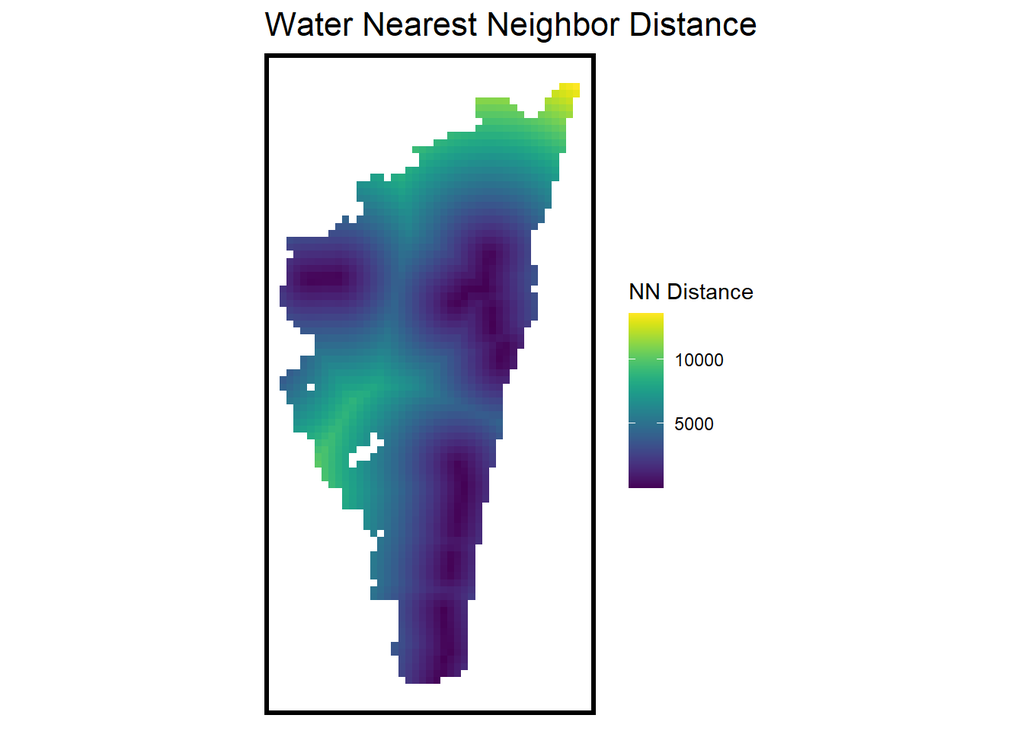

```r
vars_net_water <- knnfishnet(fishnet,chen_water_point,3)

vars_net_water.long.nn <-
  dplyr::select(vars_net_water, ends_with(".nn")) %>%
    gather(Variable, value, -geometry)

ggplot() +
      geom_sf(data = vars_net_water.long.nn, aes(fill=value), colour=NA) +
      scale_fill_viridis(name="NN Distance") +
      labs(title="Water Nearest Neighbor Distance") +
      mapTheme()
```

### 3.2.4 Waste Manageament

Here we can make two assumptions regarding the influence of waste management and its effects on litter distribution:

1. The waste management facilities reduces the surrounding litter.
2. The facilities are distant from places of high human activity, not necessarily implying that its location reduces its surrounding litter.

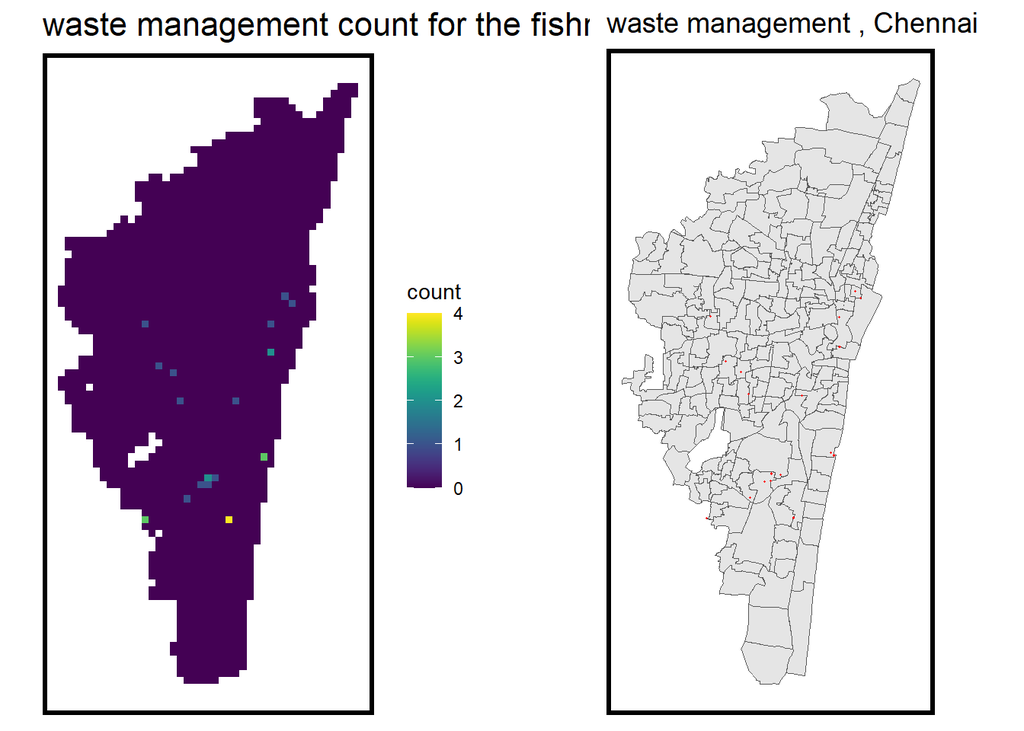

```r
chen_waste <- opq(bbox = chen_bd) %>%
    add_osm_feature(key = 'amenity', value = amenity_wm)%>%
  osmdata_sf()

chen_waste_point <- pluck(chen_waste,'osm_points')%>%
  dplyr::select(osm_id,geometry)%>%
  st_transform('EPSG:32643')

waste_net <- countfishnet(fishnet,chen_waste_point)
visual(waste_net,chen_waste_point,'waste management')
```

```r
corr_waste_net <- waste_net %>%
  left_join(litter_no, by = "uniqueID")
print(chisq.test(corr_waste_net$count,corr_waste_net$countlitter))
```

```
##
##  Pearson's Chi-squared test
##
## data:  corr_waste_net$count and corr_waste_net$countlitter
## X-squared = 0.33595, df = 112, p-value = 1
```

#### 3.2.4.1 Fishnet, Waste Manageament

We notice most waste management facilities are central and south in the city, showing mild correlations between previous variables and the urban core & coastline where we wish to prevent litter accumulation from occurring.

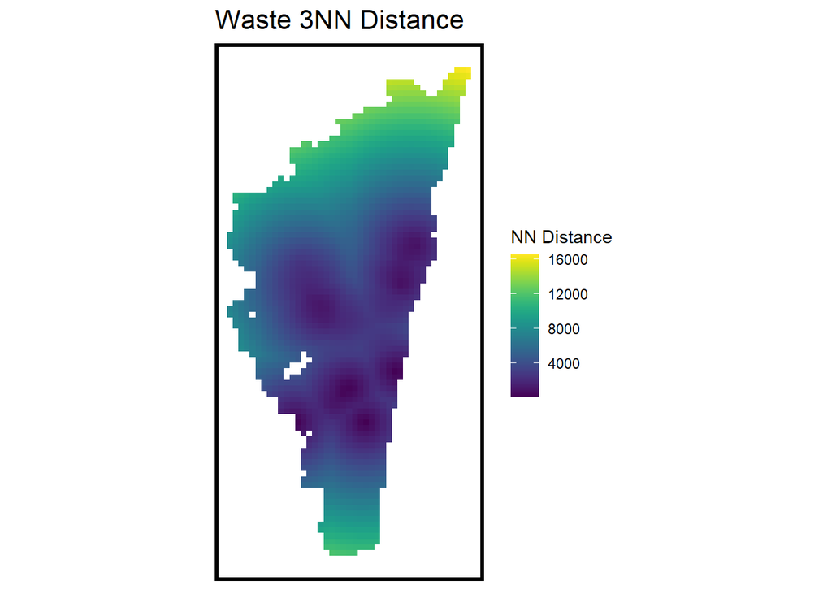

```r
vars_net_waste <- knnfishnet(fishnet,chen_waste_point,3)

vars_net_waste1.long.nn <-
  dplyr::select(vars_net_waste, ends_with(".nn")) %>%
    gather(Variable, value, -geometry)

ggplot() +
      geom_sf(data = vars_net_waste1.long.nn, aes(fill=value), colour=NA) +
      scale_fill_viridis(name="NN Distance") +
      labs(title="Waste 3NN Distance") +
      mapTheme()
```

```r
vars_net_rstrt <- knnfishnet(fishnet,restrt_point,3)
final_net <-
  left_join(litter_net, st_drop_geometry(vars_net_rstrt), by="uniqueID")
```

```r
final_net.nb <- poly2nb(as_Spatial(final_net), queen=TRUE)
final_net.weights <- nb2listw(final_net.nb, style="W", zero.policy=TRUE)
```

# 4 Spatial Analysis

We look at several statistical measurements to improve our understanding of how these independent variables correlation and associate with the litter data.

Litter_Count: Shows the raw measurement of litter found throughout the city

Local Moran’s I: Measures spatial autocorrelation among litter within the city, there is mostly no autocorrelation with a potential exception in the northern tip.

P Value: Records statistical significance, there is a peculiar pattern made for areas that are not considered significant which may question is potential insight to be gained from this particular evaluation.

Significant Hotspot: Detects potential hotspots for litter, which appears to not directly relate where litter counts are found to be.

```r
## see ?localmoran
local_morans <- localmoran(final_net$item.nn, final_net.weights, zero.policy=TRUE) %>%
  as.data.frame()

# join local Moran's I results to fishnet
final_net.localMorans <-
  cbind(local_morans, as.data.frame(final_net)) %>%
  st_sf() %>%
  dplyr::select(Litter_Count = countlitter,
                Local_Morans_I = Ii,
                P_Value = `Pr(z != E(Ii))`) %>%
  mutate(Significant_Hotspots = ifelse(P_Value <= 0.001, 1, 0)) %>%
  gather(Variable, Value, -geometry)
```

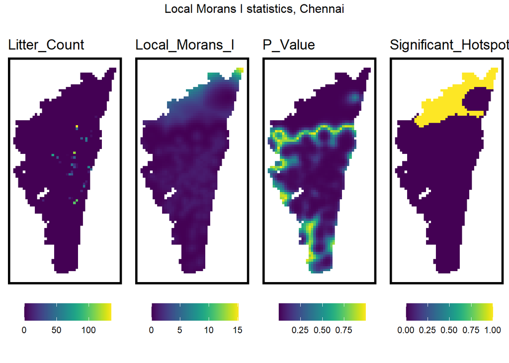

```r
vars <- unique(final_net.localMorans$Variable)
varList <- list()

for(i in vars){
  varList[[i]] <-
    ggplot() +
      geom_sf(data = filter(final_net.localMorans, Variable == i),
              aes(fill = Value), colour=NA) +
      scale_fill_viridis(name="") +
      labs(title=i) +
      mapTheme(title_size = 14) + theme(legend.position="bottom")}

do.call(grid.arrange,c(varList, ncol = 4, top = "Local Morans I statistics, Chennai"))
```

```r
final_net <- final_net %>%
  mutate(restaurant.isSig =
           ifelse(local_morans[,5] <= 0.001, 1, 0)) %>%
  mutate(restaurant.isSig.dist =
           nn_function(st_c(st_coid(final_net)),
                       st_c(st_coid(filter(final_net,
                                           restaurant.isSig == 1))),
                       k = 1))
```

## 4.1 Restaurant Significance

Restaurants are used as a point of significance because of their relation to commercial activity. We notice here there is more ‘NN Distance’ in the north due to the lack of restaurants and general activity.

```r
weight_net <-
  left_join(litter_net, st_drop_geometry(road_net), by="uniqueID")
weight_net <- weight_net %>% rename(countroad = count) %>% dplyr::select(!starts_with('cv'))

weight_net <-
  left_join(weight_net, st_drop_geometry(water_net), by="uniqueID")
weight_net <- weight_net %>% rename(countwater = count) %>% dplyr::select(!starts_with('cv'))

weight_net <-
  left_join(weight_net, st_drop_geometry(rstrt_net), by="uniqueID")
weight_net <- weight_net %>% rename(countrstrt = count) %>% dplyr::select(!starts_with('cv'))
```

## 4.2 Concluded Results

With all considered in terms of all statistical tests and independent variables measured, water and restaurants act as the greatest associated indicators for litter accumulation. Regarding other aspects and measurements considered, such as Moran’s I and and hotspots, there is sufficient data to, at minimum, evaluate model performance in assessing litter accumulation. It is noted that additional variables that build upon litter assessment will enhance the model’s accuracy. This run-through acts as the initial development process in the machine-learning approach to Urban Ocean’s objectives and needs.

# 5 Modeling

In light of the inherent bias stemmed from litter data, we also are developing a ‘Reduced Bias’ Model in attempt to compensate for potential assumptions made by the model in terms of quantity. We take each indicator and coalesce them into a single variable used for our model to compare litter data to the indicators.

```r
knnfishnet_new <- function(fishnet,dataset,knum){
  vars_net <- dataset%>%
    st_join(fishnet, join=st_within) %>%
    st_drop_geometry() %>%
    group_by(uniqueID,legend) %>%
    summarize(count = n()) %>%
    left_join(fishnet, ., by = "uniqueID") %>%
    spread(legend, count, fill=0) %>%
    dplyr::select(-`<NA>`) %>%
    ungroup()
  vars_net <- vars_net %>%
    mutate(item.nn = nn_function(st_c(st_coid(vars_net)),
                                           st_c(dataset),
                                           k = knum))
  return(vars_net)
}

rest_net_temp <- knnfishnet_new(fishnet,restrt_point,3)
tran_net_temp <- knnfishnet_new(fishnet,trans_point,3)
water_net_temp <- knnfishnet_new(fishnet,chen_water_point,3)
```

## 5.1 Visualizing Variables and Analysis

This model requires us to re-examine similar or duplicate variables and measuring their integrity for acting as indicators of litter. We are specifically looking at the nearest neighbor index to evaluate the clustering created by each variable or any correlated patterns paralleled by litter data.

### 5.1.1 Nearest Neighbor Series

Here, we further examine the nearest neighbor distances of restaurants, roads, and water, all of which have identical patterns to previous analyses. Each has a somewhat similar outcome to nearest neighbor maps prior, and do not provide insight on litter accumulation alone.

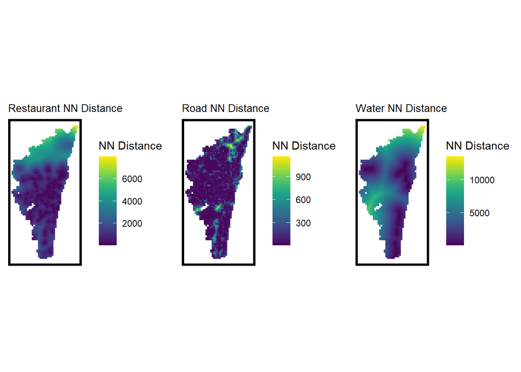

```r
rest_net_temp.long.nn <-
  dplyr::select(rest_net_temp, ends_with(".nn")) %>%
    gather(Variable, value, -geometry)

tran_net_temp.long.nn <-
  dplyr::select(tran_net_temp, ends_with(".nn")) %>%
    gather(Variable, value, -geometry)

water_net_temp.long.nn <-
  dplyr::select(water_net_temp, ends_with(".nn")) %>%
    gather(Variable, value, -geometry)

grid.arrange(
ggplot() +
      geom_sf(data = rest_net_temp.long.nn, aes(fill=value), colour=NA) +
      scale_fill_viridis(name="NN Distance") +
      labs(title="Restaurant NN Distance")+
      mapTheme()+
      theme(plot.title = element_text(size = 10, hjust = 0)),
ggplot() +
      geom_sf(data = tran_net_temp.long.nn, aes(fill=value), colour=NA) +
      scale_fill_viridis(name="NN Distance") +
      labs(title="Road NN Distance") +
      mapTheme()+
      theme(plot.title = element_text(size = 10, hjust = 0)),
ggplot() +
      geom_sf(data = water_net_temp.long.nn, aes(fill=value), colour=NA) +
      scale_fill_viridis(name="NN Distance") +
      labs(title="Water NN Distance") +
      mapTheme()+
      theme(plot.title = element_text(size = 10, hjust = 0)),
nrow = 1)
```

```r
final_net <-
  left_join(litter_net, st_drop_geometry(rest_net_temp), by="uniqueID")

final_net <-
  left_join(final_net, st_drop_geometry(tran_net_temp), by="uniqueID")

final_net <-
  left_join(final_net, st_drop_geometry(water_net_temp), by="uniqueID")%>%
  rename(rst_nn = item.nn.x,
         road_nn = item.nn.y,
         wtr_nn = item.nn)
```

```r
final_net.nb <- poly2nb(as_Spatial(final_net), queen=TRUE)
## ... and neighborhoods to list of weights
final_net.weights <- nb2listw(final_net.nb, style="W", zero.policy=TRUE)
```

```r
local_morans_rst <- localmoran(final_net$restaurant, final_net.weights, zero.policy=TRUE) %>%
  as.data.frame()
local_morans_road <- localmoran(final_net$road, final_net.weights, zero.policy=TRUE) %>%
  as.data.frame()
local_morans_wtr <- localmoran(final_net$water, final_net.weights, zero.policy=TRUE) %>%
  as.data.frame()
```

### 5.1.2 Statistic Analysis, Restaurants

Restaurants function as the great association with litter currently presented in the model. In terms of the model theory, the restaurants themselves are not the direct cause of litter but are present in areas that have high traffic/density of people, proximity of commercial activity, and overall are in areas with large flows of goods and people, indirectly associating with litter accumulation. Restaurants function less as litter accumulation places but proxies to signify high human activity.

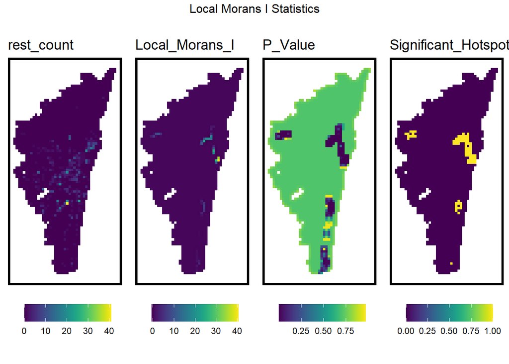

```r
final_net.localMorans <-
  cbind(local_morans_wtr, as.data.frame(final_net)) %>%
  st_sf() %>%
  dplyr::select(rest_count = restaurant,
                Local_Morans_I = Ii,
                P_Value = `Pr(z != E(Ii))`) %>%
  mutate(Significant_Hotspots = ifelse(P_Value <= 0.001, 1, 0)) %>%
  gather(Variable, Value, -geometry)

vars <- unique(final_net.localMorans$Variable)
varList <- list()

for(i in vars){
  varList[[i]] <-
    ggplot() +
      geom_sf(data = filter(final_net.localMorans, Variable == i),
              aes(fill = Value), colour=NA) +
      scale_fill_viridis(name="") +
      labs(title=i) +
      mapTheme(title_size = 14) + theme(legend.position="bottom")}

do.call(grid.arrange,c(varList, ncol = 4, top = "Local Morans I Statistics"))
```

```r
final_net <- final_net %>%
  mutate(rstrt.isSig =
           ifelse(local_morans_rst[,5] <= 0.001, 1, 0)) %>%
  mutate(rstrt.isSig.dist =
           nn_function(st_c(st_coid(final_net)),
                       st_c(st_coid(filter(final_net,
                                           rstrt.isSig == 1))),
                       k = 1))

final_net <- final_net %>%
  mutate(road.isSig =
           ifelse(local_morans_road[,5] <= 0.001, 1, 0)) %>%
  mutate(road.isSig.dist =
           nn_function(st_c(st_coid(final_net)),
                       st_c(st_coid(filter(final_net,
                                           road.isSig == 1))),
                       k = 1))

final_net <- final_net %>%
  mutate(wtr.isSig =
           ifelse(local_morans_wtr[,5] <= 0.001, 1, 0)) %>%
  mutate(wtr.isSig.dist =
           nn_function(st_c(st_coid(final_net)),
                       st_c(st_coid(filter(final_net,
                                           wtr.isSig == 1))),
                       k = 1))
```

```r
reg.ss.vars <- c("rst_nn", "rstrt.isSig.dist","road_nn", "road.isSig.dist","wtr_nn", "wtr.isSig.dist")

## RUN REGRESSIONS
reg.ss.spatialCV <- crossValidate(
  dataset = final_net,
  id = "uniqueID",
  dependentVariable = "countlitter",
  indVariables = reg.ss.vars) %>%
    dplyr::select(uniqueID, countlitter, Prediction, geometry)
```

# 6 Model Results

After a full analysis on variables, model development, and statistical evaluation of all relations, we developed an assessment model. The results that follow examine the numeric, visual, and decision implications of the model’s outcome. The goal of the results is to evaluate the general accuracy of the model in terms of Chennai alone, detect the potential accumulation assessment zones, and adjust the framework for generalizability for other cities.

## 6.1 Mean Absolute Error of Model

We see negligible error for vast majority of litter. These results do not relate to the potential of other cities but act as a benchmark in the current stage of development. Majority of litter points are not considered to be subject to absolute error.

```r
error_by_reg_and_fold <-
  reg.ss.spatialCV %>%
    group_by(uniqueID) %>%
    summarize(Mean_Error = mean(Prediction - countlitter, na.rm = T),
              MAE = mean(abs(Mean_Error), na.rm = T),
              SD_MAE = mean(abs(Mean_Error), na.rm = T)) %>%
  ungroup()

error_by_reg_and_fold %>%
  arrange(desc(MAE))

error_by_reg_and_fold %>%
  arrange(MAE)
```

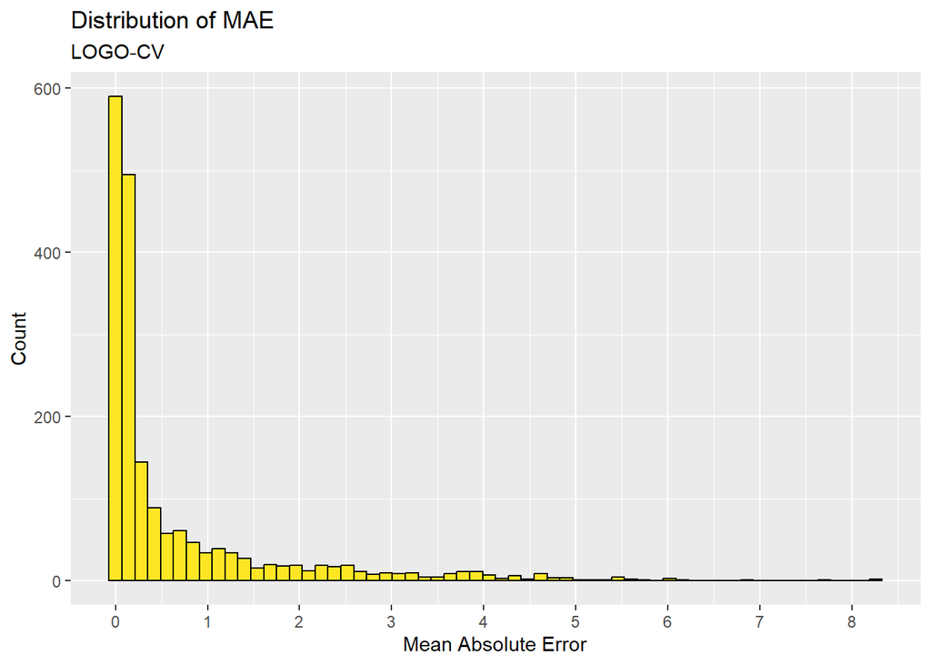

```r
error_by_reg_and_fold %>% filter(MAE <=10) %>%
  ggplot(aes(MAE)) +
    geom_histogram(bins = 60, colour="black", fill = "#FDE725FF") +
  scale_x_continuous(breaks = seq(0, 11, by = 1)) +
    labs(title="Distribution of MAE", subtitle = "LOGO-CV",
         x="Mean Absolute Error", y="Count")
```

```r
ml_breaks <- classIntervals(reg.ss.spatialCV$Prediction,
                             n = 5, "fisher")
litter_risk_sf <-
  reg.ss.spatialCV %>%
  mutate(label = "Assessment Predictions",
         Risk_Category =classInt::findCols(ml_breaks),
         Risk_Category = case_when(
           Risk_Category == 5 ~ "5th",
           Risk_Category == 4 ~ "4th",
           Risk_Category == 3 ~ "3rd",
           Risk_Category == 2 ~ "2nd",
           Risk_Category == 1 ~ "1st")) %>%
  cbind(
    aggregate(
      dplyr::select(litter_p) %>% mutate(litterCount = 1), ., sum) %>%
      mutate(litterCount = replace_na(litterCount, 0))) %>%
  dplyr::select(label,Risk_Category, litterCount)
```

## 6.2 Predictions & Results by Category

When looking at the current litter points (red dots), we see a vague circularly pattern for the larger core. The model appears to notice this pattern and is stating there is potential litter in the center of the “circle” where pre-recorded litter encircles yet feature zero data points.

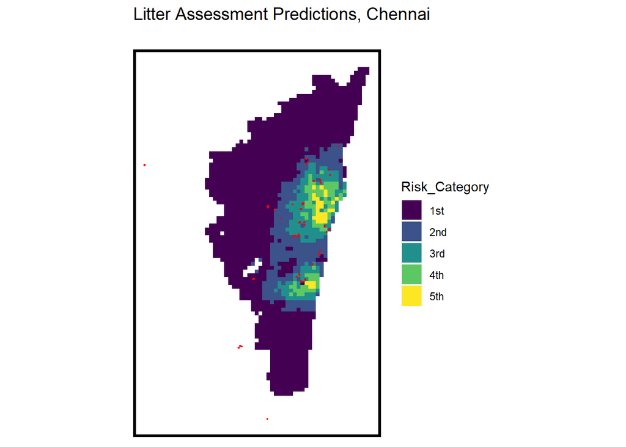

```r
ggplot() +
    geom_sf(data = litter_risk_sf, aes(fill = Risk_Category), colour = NA) +
    geom_sf(data = litter_p, size = .3, colour = "red") +
    scale_fill_viridis(discrete = TRUE) +
    labs(title="Litter Assessment Predictions, Chennai",
         subtitle="") +
    mapTheme(title_size = 14)
```

## 6.3 Compensating Bias Experiment

Assuming litter found in one spot means litter found in its surrounding, we created random points in the surrounding area to act as additional to data quantity.

```r
generate_populated_points <- function(litter_df) {
  populated_points_df <- data.frame(
    list_name = character(),
    master_item_name = character(),
    master_material = character(),
    itemname = character(),
    material = character(),
    quantity = numeric(),
    description = character(),
    latitude = numeric(),
    longitude = numeric(),
    altitude = numeric(),
    radius = numeric(),
    location = character(),
    timestamp = character(),
    dt = character(),
    project_name = character(),
    username = character(),
    manual_upload = character(),
    event_name = character(),
    id = character(),
    log_index = numeric(),
    legend = character()
  )

  for (i in 1:nrow(litter_df)) {
    center_lat <- litter_df$latitude[i]
    center_lon <- litter_df$longitude[i]

    # generate points from 1 to 20, change the num to change the range
    num_points <- sample(1:20, 1)

    for (j in 1:num_points) {
      new_lat <- center_lat + runif(1, -0.0045, 0.0045)
      new_lon <- center_lon + runif(1, -0.0045, 0.0045)

      new_row <- litter_df[i, ]
      new_row$latitude <- new_lat
      new_row$longitude <- new_lon
      new_row$legend <- 'allrandom'

      populated_points_df <- rbind(populated_points_df, new_row)
    }
  }

  return(populated_points_df)
}

# test
allrandom_points_df <- generate_populated_points(litter)
```

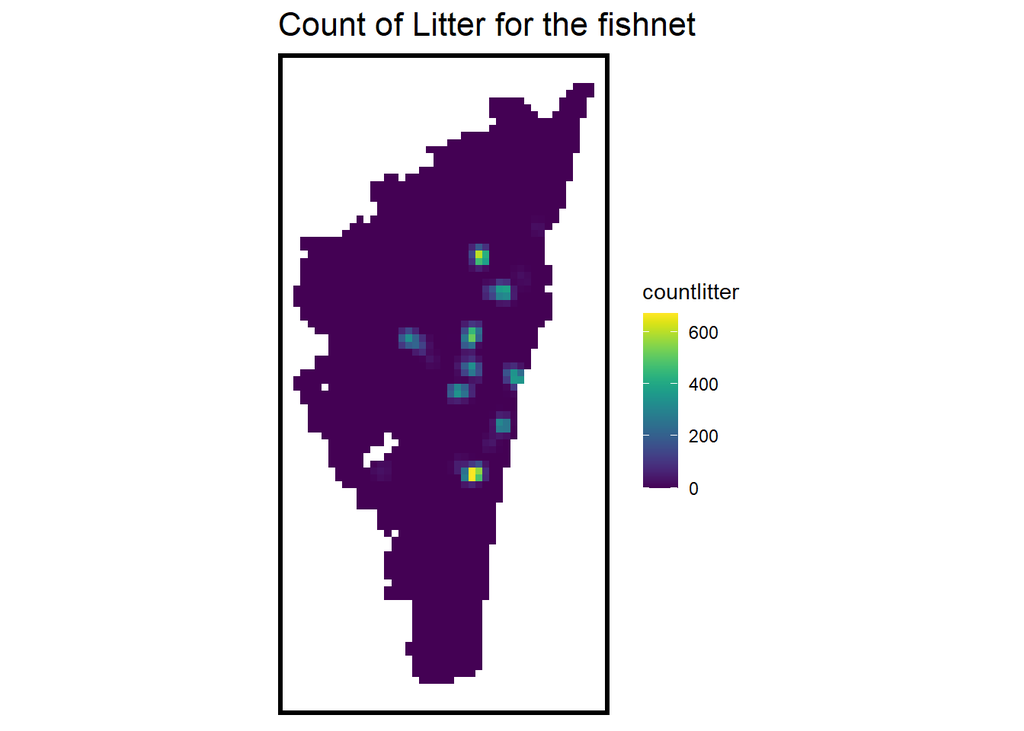

```r
allrandom_points_df <- allrandom_points_df%>%
  st_as_sf(coords = c("longitude", "latitude"), crs = 4326, agr = "constant")%>%
  st_transform('EPSG:32643')

litter_net_new <-
  dplyr::select(allrandom_points_df) %>%
  mutate(countlitter = 1) %>%
  aggregate(., fishnet, sum) %>%
  mutate(countlitter = replace_na(countlitter, 0),
         uniqueID = 1:n(),
         cvID = sample(round(nrow(fishnet) / 24),
                       size=nrow(fishnet), replace = TRUE))

ggplot() +
  geom_sf(data = litter_net_new, aes(fill = countlitter), color = NA) +
  scale_fill_viridis() +
  labs(title = "Count of Litter for the fishnet") +
  mapTheme()
```

```r
final_net_new <-
  left_join(litter_net_new, st_drop_geometry(rest_net_temp), by="uniqueID")

final_net_new <-
  left_join(final_net_new, st_drop_geometry(tran_net_temp), by="uniqueID")

final_net_new <-
  left_join(final_net_new, st_drop_geometry(water_net_temp), by="uniqueID")%>%
  rename(rst_nn = item.nn.x,
         road_nn = item.nn.y,
         wtr_nn = item.nn)
```

```r
local_morans_rst_n <- localmoran(final_net_new$restaurant, final_net.weights, zero.policy=TRUE) %>%
  as.data.frame()
local_morans_road_n <- localmoran(final_net_new$road, final_net.weights, zero.policy=TRUE) %>%
  as.data.frame()
local_morans_wtr_n <- localmoran(final_net_new$water, final_net.weights, zero.policy=TRUE) %>%
  as.data.frame()
```

```r
final_net_new <- final_net_new %>%
  mutate(rstrt.isSig =
           ifelse(local_morans_rst_n[,5] <= 0.001, 1, 0)) %>%
  mutate(rstrt.isSig.dist =
           nn_function(st_c(st_coid(final_net_new)),
                       st_c(st_coid(filter(final_net_new,
                                           rstrt.isSig == 1))),
                       k = 1))

final_net_new <- final_net_new %>%
  mutate(road.isSig =
           ifelse(local_morans_road_n[,5] <= 0.001, 1, 0)) %>%
  mutate(road.isSig.dist =
           nn_function(st_c(st_coid(final_net_new)),
                       st_c(st_coid(filter(final_net_new,
                                           road.isSig == 1))),
                       k = 1))

final_net_new <- final_net_new %>%
  mutate(wtr.isSig =
           ifelse(local_morans_wtr_n[,5] <= 0.001, 1, 0)) %>%
  mutate(wtr.isSig.dist =
           nn_function(st_c(st_coid(final_net_new)),
                       st_c(st_coid(filter(final_net_new,
                                           wtr.isSig == 1))),
                       k = 1))
```

```r
reg.ss.vars <- c("rst_nn", "rstrt.isSig.dist","road_nn", "road.isSig.dist","wtr_nn", "wtr.isSig.dist")

## RUN REGRESSIONS
reg.ss.spatialCV_new <- crossValidate(
  dataset = final_net_new,
  id = "uniqueID",
  dependentVariable = "countlitter",
  indVariables = reg.ss.vars) %>%
    dplyr::select(uniqueID, countlitter, Prediction, geometry)
```

### 6.3.1 Bias Reduction Model Results

The potential issue with litter data is due to quantity and unrecorded amounts. Litter that is recorded and disposed of, despite campaigns and efforts of cleanups, often leave large portions of ‘what would be data samples’ unaccounted for. In response to this inherent flaw in data collection, our alternative model creates random samples to act as auxiliary litter that, in most likelihood, was unrecorded.

#### 6.3.1.1 Bias Reduction Model, Mean Absolute Error

```r
error_by_reg_and_fold_new <-
  reg.ss.spatialCV_new %>%
    group_by(uniqueID) %>%
    summarize(Mean_Error = mean(Prediction - countlitter, na.rm = T),
              MAE = mean(abs(Mean_Error), na.rm = T),
              SD_MAE = mean(abs(Mean_Error), na.rm = T)) %>%
  ungroup()

error_by_reg_and_fold_new %>%
  arrange(desc(MAE))

error_by_reg_and_fold_new %>%
  arrange(MAE)
```

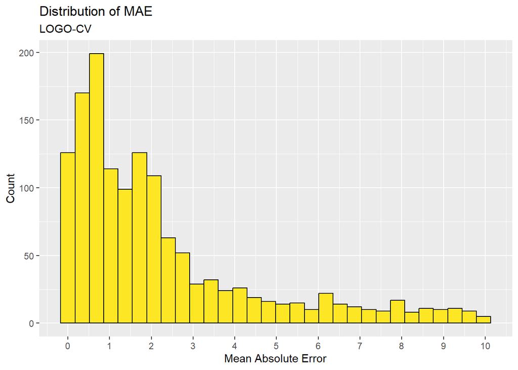

```r
error_by_reg_and_fold_new %>% filter(MAE <=10) %>%
  ggplot(aes(MAE)) +
    geom_histogram(bins = 30, colour="black", fill = "#FDE725FF") +
  scale_x_continuous(breaks = seq(0, 11, by = 1)) +
    labs(title="Distribution of MAE", subtitle = "LOGO-CV",
         x="Mean Absolute Error", y="Count")
```

```r
ml_breaks_new <- classIntervals(reg.ss.spatialCV_new$Prediction,
                             n = 5, "fisher")
litter_risk_sf_new <-
  reg.ss.spatialCV_new %>%
  mutate(label = "Assessment Predictions",
         Risk_Category =classInt::findCols(ml_breaks_new),
         Risk_Category = case_when(
           Risk_Category == 5 ~ "5th",
           Risk_Category == 4 ~ "4th",
           Risk_Category == 3 ~ "3rd",
           Risk_Category == 2 ~ "2nd",
           Risk_Category == 1 ~ "1st")) %>%
  cbind(
    aggregate(
      dplyr::select(allrandom_points_df) %>% mutate(litterCount = 1), ., sum) %>%
      mutate(litterCount = replace_na(litterCount, 0))) %>%
  dplyr::select(label,Risk_Category, litterCount)
```

#### 6.3.1.2 Bias Reduction Model Prediction

We see similar results as from the first model further proving the integrity of the data evaluated prior. Despite the additional data points that are meant to spread out the evaluation, we see a circular shape forming on the central north section adjacent to the edge. Because the boundary (water) is on the east, and there is litter developing an encirclement, the model detect the potential for litter to most likely occur within that circle. After all, restaurants are present in the ‘category 5’ area just as much as the surroundings, yet no litter was recorded there. These results bring hope to our model’s capabilities in advancing Urban Ocean’s goals as it aims to assess litter accumulation in cities around the world.

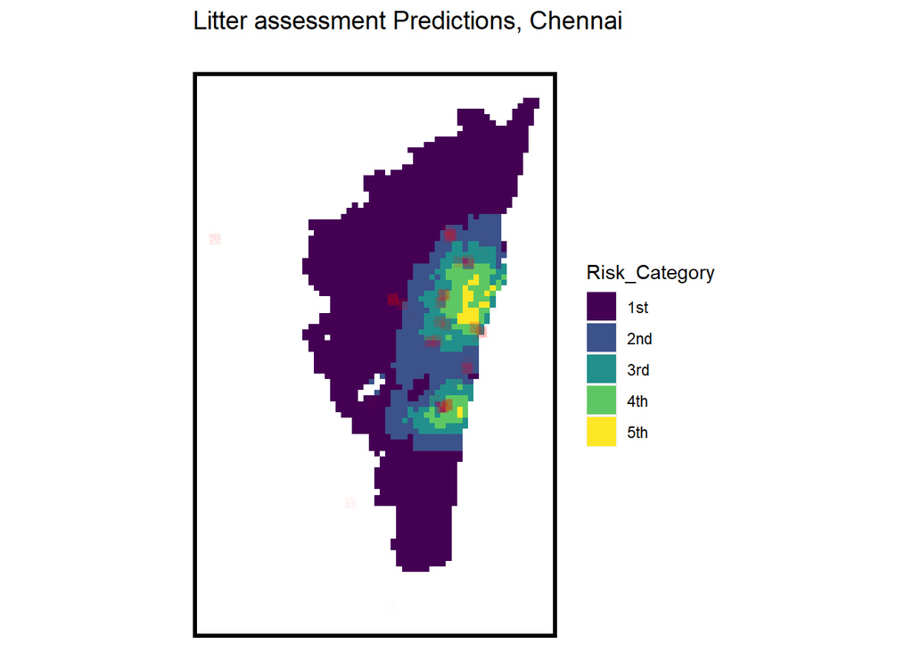

```r
ggplot() +
    geom_sf(data = litter_risk_sf_new, aes(fill = Risk_Category), colour = NA) +
    geom_sf(data = allrandom_points_df, size = .01,alpha = 0.01, colour = "red") +
    scale_fill_viridis(discrete = TRUE) +
    labs(title="Litter assessment Predictions, Chennai",
         subtitle="") +
    mapTheme(title_size = 14)
```

# 7 Next Steps

## 7.1 Random Forest Model Attempt

We will be continuing our modeling process by attempting different kinds of models, including a random forest model. These models will be completed and properly evaluated in the future.

```r
buildRFModel <- function(dataset, dependentVariable, indVariables,
                         testFraction = 0.2, ntree = 500, mtry = NULL, nodesize = 1) {
  # Split dataset into training and testing sets
  set.seed(123) # For reproducibility
  total_rows <- nrow(dataset)
  test_rows <- sample(1:total_rows, size = floor(total_rows * testFraction))

  train_set <- dataset[-test_rows, ]
  test_set <- dataset[test_rows, ]

  # Fit Random Forest model
  rfModel <- randomForest(x = train_set[indVariables],
                          y = train_set[[dependentVariable]],
                          ntree = ntree,
                          mtry = mtry,
                          nodesize = nodesize)

  # Make predictions on the test set
  predictions <- predict(rfModel, newdata = test_set[indVariables])

  # Evaluate model performance
  actual <- test_set[[dependentVariable]]

  # Example of a simple evaluation metric: Mean Squared Error (MSE)
  mse <- mean((predictions - actual) ^ 2)

  cat("Model MSE:", mse, "\n")

  return(list(model = rfModel, mse = mse))
}
```